# Skims Munich–Bavaria: PT (segmented) and car

Morning peak 07:30–08:30

**About**

### What this report shows

Zone-to-zone skims for **5452 zones** (29,724,304 OD pairs), calculated with `CalculateSegmentedSkimsMuc` (written 2026-11-17). Five zones can be inspected in detail: **2641 München-Moosach, 3441 München-Fürstenried West, 517 Augsburg, 4405 Rosenheim, 3084 München-Maxvorstadt**. Region-wide plots use all OD pairs (maps, box plots) or a random sample of 2e+05 interzonal OD pairs (scatter plots).

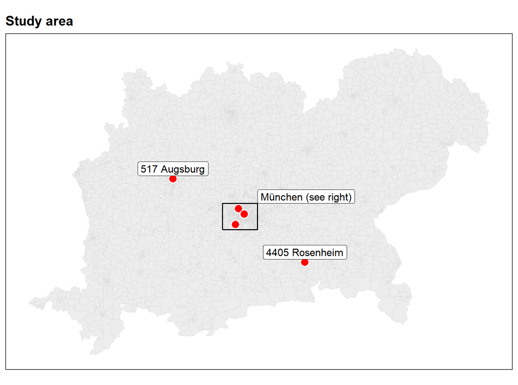

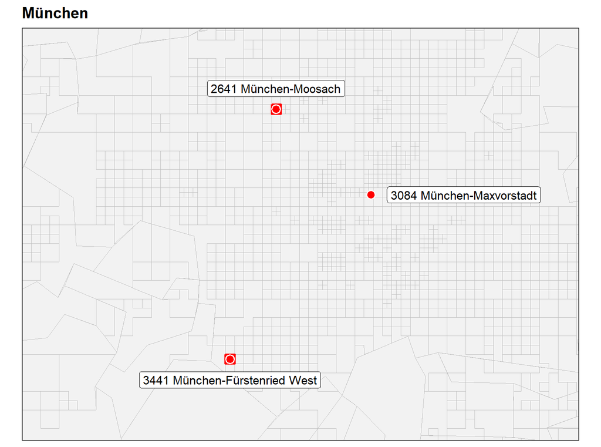

### Skims

| Skim | Network / schedule | Main mode | Feeder modes |
| --- | --- | --- | --- |
| car | car network, free-flow speed | car | – |
| bus | bus (+ ferry) | bus, ferry | – |
| bus + tram/metro | bus + tram + U-Bahn | tram, U-Bahn | bus, ferry |
| bus + tram/metro + rail | all PT | rail (S-Bahn, regional trains) | bus, ferry, tram, U-Bahn |

### Settings

| Setting | Value |
| --- | --- |
| Departure window (PT) | 07:30–08:30; routing trees every 120 s from 06:30 to 09:30 |
| Sampling points | 3 per zone; all skims use the same points |
| Walking | 3 km/h, straight-line distance × 1.3 |
| Stop search radius | 1,000 m (+200 m if no stop is found) |
| Max. transfer walk | 500 m straight-line |
| Car | free-flow speeds (no congestion) |

### Definitions

| Term | Meaning |
| --- | --- |
| Total travel time | door to door: walk access + in-vehicle time + transfer walk + transfer wait + walk egress. Waiting at the first stop is **not** included (it is in the adaption time). |
| PT access / main / egress | in-vehicle time before the first main-mode leg / from the first to the last main-mode leg / after the last main-mode leg |
| Main share | in-vehicle time on the main segment ÷ total in-vehicle time. 1 = no feeder legs. |
| Availability | share of the hour (and of the 3 × 3 point pairs) in which the best connection uses the main mode. **Car:** 1 if the car time is finite, 0 otherwise. |
| Share reachable | per origin zone: share of all other zones with a finite travel time |
| No connection (`Infinity`) | no connection using the main mode at all. Shown in grey on maps and as “–” in tables. |
| Door-to-door speed | straight-line distance ÷ total travel time |

Note: for very short and intrazonal trips the PT values are unreliable (stops near the destination are reached “walking only” and are skipped by the router). Use the walk skim for those.

### Overall

| mode | share of OD pairs reachable [%] | mean availability | median main share | median travel time [min] |
| --- | --- | --- | --- | --- |
| car | 100.0 | 1.00 | – | 52 |
| bus | 96.0 | 0.94 | 1.00 | 273 |
| bus + tram/metro | 70.6 | 0.63 | 0.15 | 243 |
| bus + tram/metro + rail | 93.4 | 0.90 | 0.76 | 141 |

**Zone explorer**

**2641 München-Moosach**

**Travel times from 2641 München-Moosach to the other selected zones** (minutes; first row group: intrazonal)

| to | mode | beeline km | total min | walk acc | PT acc | PT main | PT egr | walk egr | trf walk | trf wait | transfers | main share | availability | freq /h | dist km |
| --- | --- | --- | --- | --- | --- | --- | --- | --- | --- | --- | --- | --- | --- | --- | --- |
| 2641 München-Moosach | car | 0.2 | 2.4 | – | – | – | – | – | – | – | – | – | 1.00 | – | 1.7 |
| 2641 München-Moosach | bus | 0.2 | 32.4 | 7.5 | 0.0 | 3.7 | 0.0 | 21.2 | 0.0 | 0.0 | 0.00 | 1.00 | 0.67 | 4.5 | 2.5 |
| 2641 München-Moosach | bus + tram/metro | 0.2 | 33.0 | 4.1 | 0.0 | 3.5 | 0.0 | 25.3 | 0.0 | 0.0 | 0.00 | 1.00 | 0.11 | 5.1 | 2.7 |
| 2641 München-Moosach | bus + tram/metro + rail | 0.2 | – | – | – | – | – | – | – | – | – | – | 0.00 | 0.0 | – |
| 3441 München-Fürstenried West | car | 11.0 | 16.1 | – | – | – | – | – | – | – | – | – | 1.00 | – | 13.1 |
| 3441 München-Fürstenried West | bus | 11.0 | 80.3 | 4.7 | 0.0 | 57.4 | 0.0 | 12.6 | 2.2 | 3.3 | 2.08 | 1.00 | 1.00 | 4.9 | 17.1 |
| 3441 München-Fürstenried West | bus + tram/metro | 11.0 | 52.3 | 4.7 | 0.0 | 36.2 | 1.4 | 9.5 | 0.4 | 0.0 | 0.34 | 0.96 | 1.00 | 10.2 | 20.9 |
| 3441 München-Fürstenried West | bus + tram/metro + rail | 11.0 | – | – | – | – | – | – | – | – | – | – | 0.00 | 0.0 | – |
| 517 Augsburg | car | 49.2 | 39.6 | – | – | – | – | – | – | – | – | – | 1.00 | – | 62.1 |
| 517 Augsburg | bus | 49.2 | 187.0 | 6.1 | 0.0 | 144.0 | 0.0 | 6.1 | 20.6 | 10.2 | 5.00 | 1.00 | 1.00 | 0.6 | 95.5 |
| 517 Augsburg | bus + tram/metro | 49.2 | 181.8 | 6.4 | 130.1 | 13.7 | 0.0 | 3.5 | 14.0 | 14.1 | 4.63 | 0.10 | 0.68 | 0.6 | 87.7 |
| 517 Augsburg | bus + tram/metro + rail | 49.2 | 72.4 | 6.2 | 0.0 | 43.9 | 0.4 | 10.2 | 2.3 | 9.4 | 1.85 | 0.99 | 1.00 | 1.7 | 62.5 |
| 4405 Rosenheim | car | 58.6 | 51.0 | – | – | – | – | – | – | – | – | – | 1.00 | – | 75.6 |
| 4405 Rosenheim | bus | 58.6 | 302.5 | 4.1 | 0.0 | 219.0 | 0.0 | 2.8 | 13.8 | 62.8 | 7.69 | 1.00 | 1.00 | 0.4 | 124.4 |
| 4405 Rosenheim | bus + tram/metro | 58.6 | 198.2 | 4.7 | 0.0 | 32.0 | 109.0 | 2.0 | 7.8 | 42.8 | 6.00 | 0.23 | 1.00 | 0.5 | 86.7 |
| 4405 Rosenheim | bus + tram/metro + rail | 58.6 | 61.6 | 6.2 | 0.0 | 50.2 | 0.0 | 3.3 | 0.0 | 1.8 | 1.00 | 1.00 | 1.00 | 1.5 | 62.4 |
| 3084 München-Maxvorstadt | car | 5.5 | 7.6 | – | – | – | – | – | – | – | – | – | 1.00 | – | 6.6 |
| 3084 München-Maxvorstadt | bus | 5.5 | 57.3 | 3.9 | 0.0 | 35.7 | 0.0 | 6.9 | 5.8 | 4.9 | 3.51 | 1.00 | 1.00 | 4.0 | 11.5 |
| 3084 München-Maxvorstadt | bus + tram/metro | 5.5 | 27.1 | 4.7 | 0.0 | 13.9 | 0.0 | 8.3 | 0.2 | 0.0 | 0.95 | 1.00 | 1.00 | 12.8 | 8.6 |
| 3084 München-Maxvorstadt | bus + tram/metro + rail | 5.5 | 27.1 | 3.4 | 0.0 | 11.0 | 1.1 | 8.0 | 3.5 | 0.0 | 1.00 | 0.91 | 0.03 | 13.0 | 9.6 |

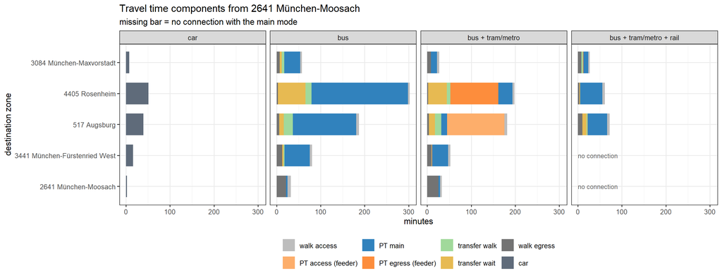

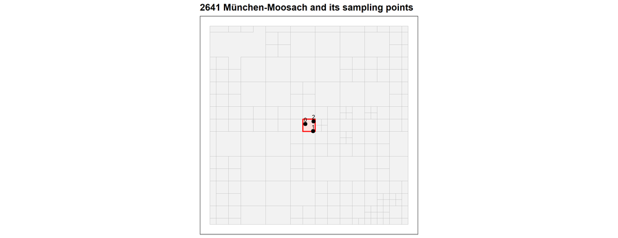

**3441 München-Fürstenried West**

**Travel times from 3441 München-Fürstenried West to the other selected zones** (minutes; first row group: intrazonal)

| to | mode | beeline km | total min | walk acc | PT acc | PT main | PT egr | walk egr | trf walk | trf wait | transfers | main share | availability | freq /h | dist km |
| --- | --- | --- | --- | --- | --- | --- | --- | --- | --- | --- | --- | --- | --- | --- | --- |
| 3441 München-Fürstenried West | car | 0.1 | 0.5 | – | – | – | – | – | – | – | – | – | 1.00 | – | 0.3 |
| 3441 München-Fürstenried West | bus | 0.1 | 40.9 | 13.0 | 0.0 | 3.2 | 0.0 | 23.0 | 0.2 | 1.4 | 0.40 | 1.00 | 0.56 | 5.4 | 2.8 |
| 3441 München-Fürstenried West | bus + tram/metro | 0.1 | 43.6 | 8.3 | 0.0 | 2.5 | 7.3 | 23.2 | 2.3 | 0.0 | 1.00 | 0.26 | 0.10 | 8.4 | 5.2 |
| 3441 München-Fürstenried West | bus + tram/metro + rail | 0.1 | – | – | – | – | – | – | – | – | – | – | 0.00 | 0.0 | – |
| 2641 München-Moosach | car | 11.0 | 16.4 | – | – | – | – | – | – | – | – | – | 1.00 | – | 13.5 |
| 2641 München-Moosach | bus | 11.0 | 77.2 | 16.1 | 0.0 | 51.2 | 0.0 | 4.9 | 4.2 | 0.9 | 1.65 | 1.00 | 1.00 | 4.6 | 15.7 |
| 2641 München-Moosach | bus + tram/metro | 11.0 | 53.4 | 12.2 | 0.0 | 36.5 | 0.0 | 4.7 | 0.0 | 0.0 | 0.00 | 1.00 | 1.00 | 12.0 | 20.8 |
| 2641 München-Moosach | bus + tram/metro + rail | 11.0 | – | – | – | – | – | – | – | – | – | – | 0.00 | 0.0 | – |
| 517 Augsburg | car | 52.8 | 48.0 | – | – | – | – | – | – | – | – | – | 1.00 | – | 72.8 |
| 517 Augsburg | bus | 52.8 | 261.5 | 13.0 | 0.0 | 165.6 | 0.0 | 5.8 | 26.1 | 51.0 | 4.96 | 1.00 | 1.00 | 0.9 | 111.2 |
| 517 Augsburg | bus + tram/metro | 52.8 | 194.3 | 12.8 | 78.7 | 41.5 | 10.5 | 3.5 | 17.9 | 29.3 | 4.44 | 0.32 | 1.00 | 0.2 | 78.5 |
| 517 Augsburg | bus + tram/metro + rail | 52.8 | 91.8 | 13.0 | 26.5 | 35.0 | 0.4 | 10.3 | 4.4 | 2.3 | 1.26 | 0.57 | 1.00 | 1.7 | 61.9 |
| 4405 Rosenheim | car | 54.4 | 48.3 | – | – | – | – | – | – | – | – | – | 1.00 | – | 74.5 |
| 4405 Rosenheim | bus | 54.4 | 289.5 | 15.1 | 0.0 | 190.5 | 0.0 | 2.6 | 15.8 | 65.5 | 5.65 | 1.00 | 1.00 | 0.3 | 103.0 |
| 4405 Rosenheim | bus + tram/metro | 54.4 | 211.2 | 12.2 | 0.0 | 34.5 | 110.1 | 2.0 | 8.0 | 44.3 | 5.95 | 0.24 | 1.00 | 0.2 | 89.3 |
| 4405 Rosenheim | bus + tram/metro + rail | 54.4 | 73.1 | 12.2 | 17.5 | 36.7 | 0.0 | 3.3 | 2.7 | 0.6 | 2.00 | 0.68 | 1.00 | 1.5 | 63.8 |
| 3084 München-Maxvorstadt | car | 9.4 | 13.2 | – | – | – | – | – | – | – | – | – | 1.00 | – | 11.6 |
| 3084 München-Maxvorstadt | bus | 9.4 | 83.7 | 16.9 | 0.0 | 50.7 | 0.0 | 7.5 | 3.9 | 4.8 | 2.33 | 1.00 | 1.00 | 4.0 | 16.0 |
| 3084 München-Maxvorstadt | bus + tram/metro | 9.4 | 42.2 | 12.2 | 0.0 | 19.9 | 0.0 | 8.1 | 1.7 | 0.3 | 1.00 | 1.00 | 1.00 | 12.0 | 12.1 |
| 3084 München-Maxvorstadt | bus + tram/metro + rail | 9.4 | – | – | – | – | – | – | – | – | – | – | 0.00 | 0.0 | – |

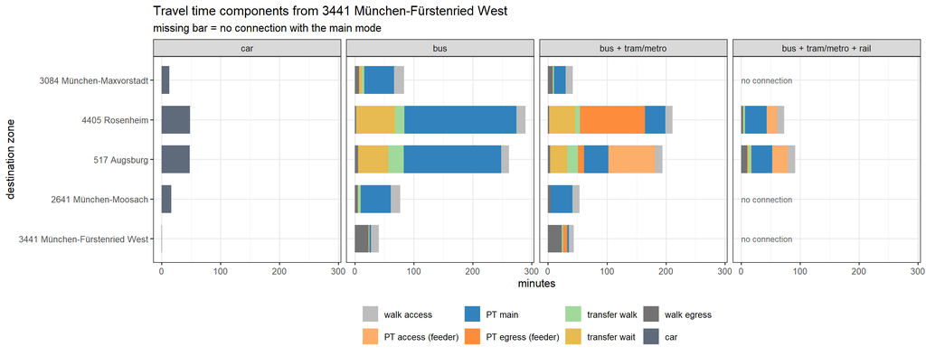

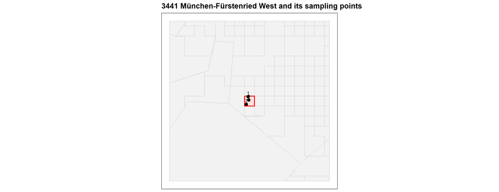

**517 Augsburg**

**Travel times from 517 Augsburg to the other selected zones** (minutes; first row group: intrazonal)

| to | mode | beeline km | total min | walk acc | PT acc | PT main | PT egr | walk egr | trf walk | trf wait | transfers | main share | availability | freq /h | dist km |
| --- | --- | --- | --- | --- | --- | --- | --- | --- | --- | --- | --- | --- | --- | --- | --- |
| 517 Augsburg | car | 0.1 | 0.5 | – | – | – | – | – | – | – | – | – | 1.00 | – | 0.3 |
| 517 Augsburg | bus | 0.1 | 40.5 | 12.4 | 0.0 | 4.0 | 0.0 | 23.7 | 0.0 | 0.4 | 0.12 | 1.00 | 0.67 | 3.9 | 2.9 |
| 517 Augsburg | bus + tram/metro | 0.1 | 30.6 | 2.8 | 0.0 | 5.0 | 0.0 | 22.8 | 0.0 | 0.0 | 0.00 | 1.00 | 0.44 | 5.0 | 2.4 |
| 517 Augsburg | bus + tram/metro + rail | 0.1 | – | – | – | – | – | – | – | – | – | – | 0.00 | 0.0 | – |
| 2641 München-Moosach | car | 49.2 | 39.2 | – | – | – | – | – | – | – | – | – | 1.00 | – | 61.3 |
| 2641 München-Moosach | bus | 49.2 | 201.4 | 20.3 | 0.0 | 129.2 | 0.0 | 5.4 | 5.0 | 41.6 | 3.63 | 1.00 | 1.00 | 0.4 | 79.5 |
| 2641 München-Moosach | bus + tram/metro | 49.2 | 147.4 | 3.2 | 0.0 | 15.0 | 97.7 | 5.9 | 9.4 | 16.3 | 5.33 | 0.13 | 1.00 | 0.5 | 65.7 |
| 2641 München-Moosach | bus + tram/metro + rail | 49.2 | 76.6 | 12.5 | 0.0 | 51.8 | 3.1 | 4.9 | 1.8 | 2.5 | 2.44 | 0.94 | 1.00 | 2.4 | 65.5 |
| 3441 München-Fürstenried West | car | 52.8 | 46.7 | – | – | – | – | – | – | – | – | – | 1.00 | – | 71.6 |
| 3441 München-Fürstenried West | bus | 52.8 | 190.6 | 9.2 | 0.0 | 120.2 | 0.0 | 10.1 | 12.2 | 39.0 | 6.33 | 1.00 | 1.00 | 0.5 | 69.2 |
| 3441 München-Fürstenried West | bus + tram/metro | 52.8 | 154.6 | 3.2 | 0.0 | 15.0 | 93.2 | 10.1 | 14.9 | 18.3 | 4.33 | 0.14 | 1.00 | 0.5 | 64.9 |
| 3441 München-Fürstenried West | bus + tram/metro + rail | 52.8 | 95.4 | 12.5 | 0.0 | 44.4 | 20.8 | 12.8 | 3.1 | 1.9 | 1.69 | 0.68 | 1.00 | 2.5 | 68.3 |
| 4405 Rosenheim | car | 107.0 | 84.2 | – | – | – | – | – | – | – | – | – | 1.00 | – | 149.8 |
| 4405 Rosenheim | bus | 107.0 | 457.1 | 8.7 | 0.0 | 303.4 | 0.0 | 4.9 | 15.4 | 124.6 | 8.15 | 1.00 | 1.00 | 0.4 | 191.9 |
| 4405 Rosenheim | bus + tram/metro | 107.0 | 376.2 | 3.2 | 0.0 | 126.5 | 132.0 | 2.0 | 16.9 | 95.6 | 9.00 | 0.49 | 1.00 | 0.5 | 153.4 |
| 4405 Rosenheim | bus + tram/metro + rail | 107.0 | 112.3 | 12.5 | 0.0 | 82.5 | 0.0 | 3.3 | 3.3 | 10.7 | 1.00 | 1.00 | 1.00 | 1.4 | 112.8 |
| 3084 München-Maxvorstadt | car | 54.5 | 44.4 | – | – | – | – | – | – | – | – | – | 1.00 | – | 66.1 |
| 3084 München-Maxvorstadt | bus | 54.5 | 207.2 | 8.8 | 0.0 | 126.3 | 0.0 | 14.0 | 12.5 | 45.5 | 6.56 | 1.00 | 1.00 | 0.3 | 76.0 |
| 3084 München-Maxvorstadt | bus + tram/metro | 54.5 | 157.4 | 3.2 | 0.0 | 110.4 | 0.0 | 8.1 | 15.4 | 20.3 | 6.00 | 1.00 | 1.00 | 0.5 | 66.6 |
| 3084 München-Maxvorstadt | bus + tram/metro + rail | 54.5 | 72.2 | 12.5 | 0.0 | 43.7 | 3.5 | 6.6 | 4.1 | 1.8 | 1.00 | 0.93 | 1.00 | 2.6 | 60.7 |

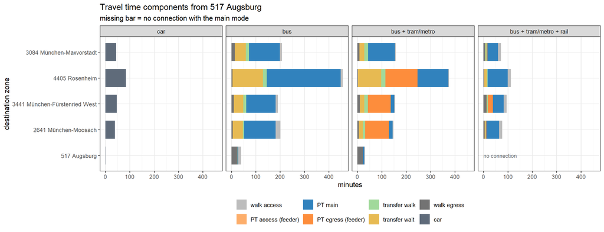

[figure not shown]

**4405 Rosenheim**

**Travel times from 4405 Rosenheim to the other selected zones** (minutes; first row group: intrazonal)

| to | mode | beeline km | total min | walk acc | PT acc | PT main | PT egr | walk egr | trf walk | trf wait | transfers | main share | availability | freq /h | dist km |
| --- | --- | --- | --- | --- | --- | --- | --- | --- | --- | --- | --- | --- | --- | --- | --- |
| 4405 Rosenheim | car | 0.0 | 0.0 | – | – | – | – | – | – | – | – | – | 1.00 | – | 0.0 |
| 4405 Rosenheim | bus | 0.0 | 40.1 | 10.0 | 0.0 | 4.5 | 0.0 | 25.6 | 0.0 | 0.0 | 0.00 | 1.00 | 0.44 | 2.6 | 3.1 |
| 4405 Rosenheim | bus + tram/metro | 0.0 | – | – | – | – | – | – | – | – | – | – | 0.00 | 0.0 | – |
| 4405 Rosenheim | bus + tram/metro + rail | 0.0 | – | – | – | – | – | – | – | – | – | – | 0.00 | 0.0 | – |
| 2641 München-Moosach | car | 58.6 | 50.5 | – | – | – | – | – | – | – | – | – | 1.00 | – | 75.2 |
| 2641 München-Moosach | bus | 58.6 | 291.1 | 2.4 | 0.0 | 182.5 | 0.0 | 4.7 | 11.3 | 90.2 | 7.00 | 1.00 | 1.00 | 0.7 | 100.5 |
| 2641 München-Moosach | bus + tram/metro | 58.6 | 240.6 | 2.4 | 109.0 | 31.2 | 0.0 | 4.4 | 13.7 | 80.0 | 6.00 | 0.22 | 1.00 | 0.7 | 95.0 |
| 2641 München-Moosach | bus + tram/metro + rail | 58.6 | 66.3 | 3.3 | 0.0 | 39.7 | 14.7 | 4.7 | 2.2 | 1.6 | 1.83 | 0.73 | 1.00 | 3.4 | 62.4 |
| 3441 München-Fürstenried West | car | 54.4 | 47.3 | – | – | – | – | – | – | – | – | – | 1.00 | – | 74.2 |
| 3441 München-Fürstenried West | bus | 54.4 | 285.2 | 2.4 | 0.0 | 163.2 | 0.0 | 14.5 | 11.3 | 93.9 | 5.33 | 1.00 | 1.00 | 0.7 | 97.8 |
| 3441 München-Fürstenried West | bus + tram/metro | 54.4 | 246.3 | 2.4 | 109.0 | 34.2 | 0.0 | 12.2 | 13.0 | 75.5 | 5.00 | 0.24 | 1.00 | 0.7 | 98.0 |
| 3441 München-Fürstenried West | bus + tram/metro + rail | 54.4 | 74.5 | 3.3 | 0.0 | 36.6 | 19.2 | 10.4 | 2.8 | 2.2 | 2.24 | 0.66 | 1.00 | 3.6 | 63.5 |
| 517 Augsburg | car | 107.0 | 83.4 | – | – | – | – | – | – | – | – | – | 1.00 | – | 150.1 |
| 517 Augsburg | bus | 107.0 | 463.7 | 2.4 | 0.0 | 248.9 | 0.0 | 5.6 | 46.8 | 160.0 | 10.00 | 1.00 | 1.00 | 0.7 | 167.6 |
| 517 Augsburg | bus + tram/metro | 107.0 | 382.2 | 5.3 | 159.0 | 106.3 | 0.0 | 3.6 | 13.2 | 94.8 | 9.00 | 0.40 | 1.00 | 0.5 | 191.6 |
| 517 Augsburg | bus + tram/metro + rail | 107.0 | 109.6 | 3.3 | 0.0 | 84.5 | 0.4 | 10.1 | 4.2 | 7.0 | 1.22 | 0.99 | 1.00 | 2.3 | 114.3 |
| 3084 München-Maxvorstadt | car | 53.2 | 43.8 | – | – | – | – | – | – | – | – | – | 1.00 | – | 69.2 |
| 3084 München-Maxvorstadt | bus | 53.2 | 255.4 | 2.4 | 0.0 | 157.5 | 0.0 | 5.0 | 10.4 | 80.1 | 5.00 | 1.00 | 1.00 | 0.7 | 90.0 |
| 3084 München-Maxvorstadt | bus + tram/metro | 53.2 | 225.6 | 2.4 | 109.0 | 21.7 | 0.0 | 8.1 | 9.9 | 74.5 | 5.00 | 0.17 | 1.00 | 0.7 | 90.0 |
| 3084 München-Maxvorstadt | bus + tram/metro + rail | 53.2 | 56.8 | 3.3 | 0.0 | 38.1 | 3.1 | 7.9 | 3.6 | 0.7 | 2.00 | 0.92 | 1.00 | 3.5 | 55.0 |

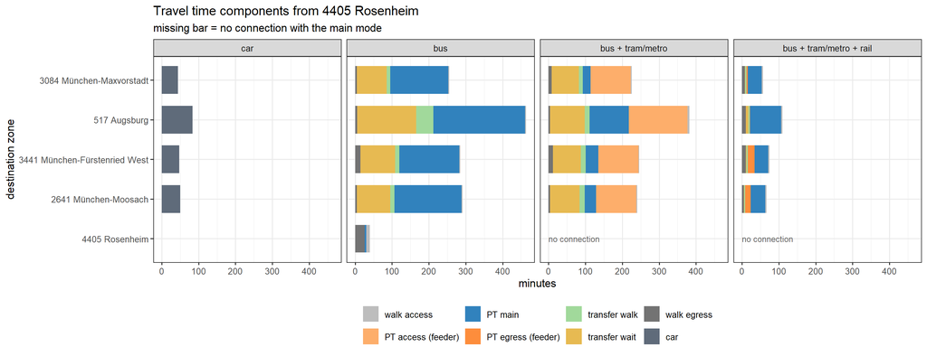

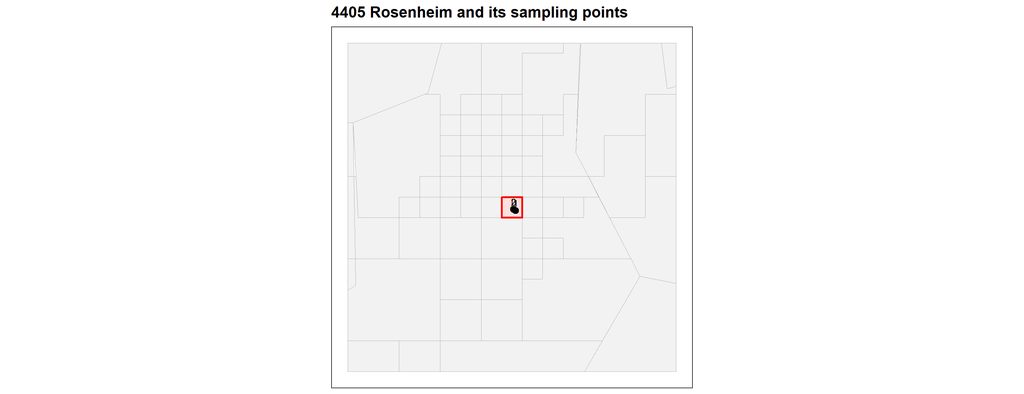

**3084 München-Maxvorstadt**

**Travel times from 3084 München-Maxvorstadt to the other selected zones** (minutes; first row group: intrazonal)

| to | mode | beeline km | total min | walk acc | PT acc | PT main | PT egr | walk egr | trf walk | trf wait | transfers | main share | availability | freq /h | dist km |
| --- | --- | --- | --- | --- | --- | --- | --- | --- | --- | --- | --- | --- | --- | --- | --- |
| 3084 München-Maxvorstadt | car | 0.1 | 0.4 | – | – | – | – | – | – | – | – | – | 1.00 | – | 0.3 |
| 3084 München-Maxvorstadt | bus | 0.1 | 44.5 | 15.9 | 0.0 | 3.6 | 0.0 | 25.0 | 0.0 | 0.0 | 0.00 | 1.00 | 0.67 | 6.6 | 2.8 |
| 3084 München-Maxvorstadt | bus + tram/metro | 0.1 | 34.8 | 8.4 | 0.0 | 3.0 | 0.0 | 23.4 | 0.0 | 0.0 | 0.00 | 1.00 | 0.22 | 6.7 | 2.5 |
| 3084 München-Maxvorstadt | bus + tram/metro + rail | 0.1 | – | – | – | – | – | – | – | – | – | – | 0.00 | 0.0 | – |
| 2641 München-Moosach | car | 5.5 | 7.5 | – | – | – | – | – | – | – | – | – | 1.00 | – | 6.6 |
| 2641 München-Moosach | bus | 5.5 | 67.0 | 16.2 | 0.0 | 41.2 | 0.0 | 4.7 | 3.2 | 1.6 | 2.02 | 1.00 | 1.00 | 6.1 | 11.3 |
| 2641 München-Moosach | bus + tram/metro | 5.5 | 27.2 | 8.2 | 0.0 | 14.2 | 0.0 | 4.7 | 0.2 | 0.0 | 0.91 | 1.00 | 1.00 | 9.5 | 8.6 |
| 2641 München-Moosach | bus + tram/metro + rail | 5.5 | – | – | – | – | – | – | – | – | – | – | 0.00 | 0.0 | – |
| 3441 München-Fürstenried West | car | 9.4 | 12.8 | – | – | – | – | – | – | – | – | – | 1.00 | – | 11.6 |
| 3441 München-Fürstenried West | bus | 9.4 | 91.9 | 27.1 | 0.0 | 44.0 | 0.0 | 13.0 | 3.6 | 4.3 | 2.36 | 1.00 | 1.00 | 4.7 | 15.4 |
| 3441 München-Fürstenried West | bus + tram/metro | 9.4 | 42.7 | 9.0 | 0.0 | 19.5 | 0.0 | 12.4 | 0.3 | 1.5 | 1.00 | 1.00 | 1.00 | 6.0 | 11.8 |
| 3441 München-Fürstenried West | bus + tram/metro + rail | 9.4 | – | – | – | – | – | – | – | – | – | – | 0.00 | 0.0 | – |
| 517 Augsburg | car | 54.5 | 44.9 | – | – | – | – | – | – | – | – | – | 1.00 | – | 66.7 |
| 517 Augsburg | bus | 54.5 | 239.9 | 17.5 | 0.0 | 177.7 | 0.0 | 5.7 | 24.7 | 14.3 | 7.00 | 1.00 | 1.00 | 0.4 | 106.5 |
| 517 Augsburg | bus + tram/metro | 54.5 | 198.4 | 8.6 | 0.0 | 127.4 | 30.8 | 4.0 | 16.7 | 10.8 | 5.00 | 0.81 | 1.00 | 0.4 | 97.1 |
| 517 Augsburg | bus + tram/metro + rail | 54.5 | 77.4 | 24.3 | 0.0 | 40.7 | 0.3 | 10.7 | 0.4 | 0.9 | 0.25 | 0.99 | 1.00 | 2.0 | 60.5 |
| 4405 Rosenheim | car | 53.2 | 43.7 | – | – | – | – | – | – | – | – | – | 1.00 | – | 69.1 |
| 4405 Rosenheim | bus | 53.2 | 220.2 | 7.7 | 0.0 | 158.3 | 0.0 | 2.0 | 3.1 | 49.1 | 6.46 | 1.00 | 1.00 | 0.2 | 88.7 |
| 4405 Rosenheim | bus + tram/metro | 53.2 | 197.8 | 24.3 | 0.0 | 16.7 | 107.7 | 2.0 | 3.8 | 43.4 | 5.00 | 0.13 | 1.00 | 0.5 | 79.1 |
| 4405 Rosenheim | bus + tram/metro + rail | 53.2 | 68.7 | 25.7 | 0.0 | 39.5 | 0.0 | 3.3 | 0.0 | 0.1 | 0.66 | 1.00 | 1.00 | 1.4 | 55.4 |

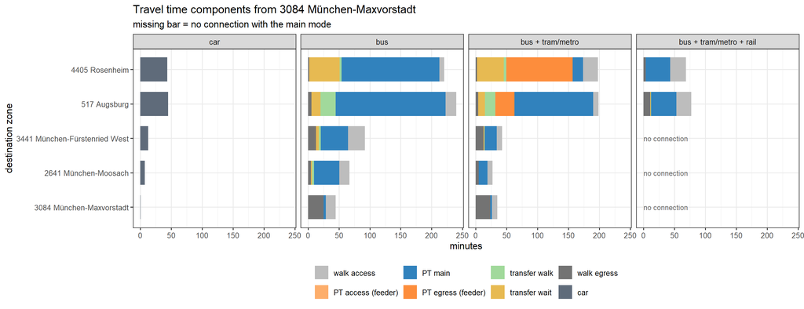

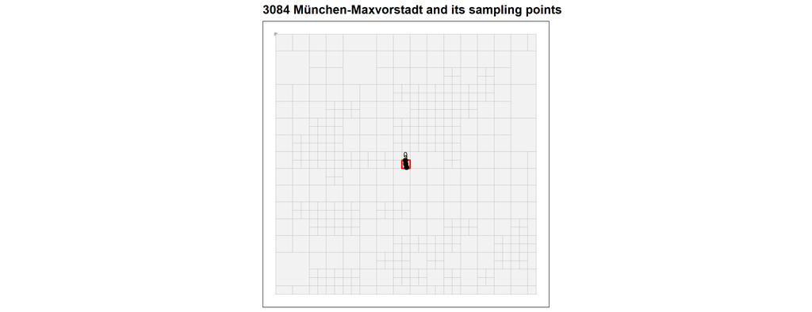

**Connectivity maps**

**From 2641 München-Moosach**

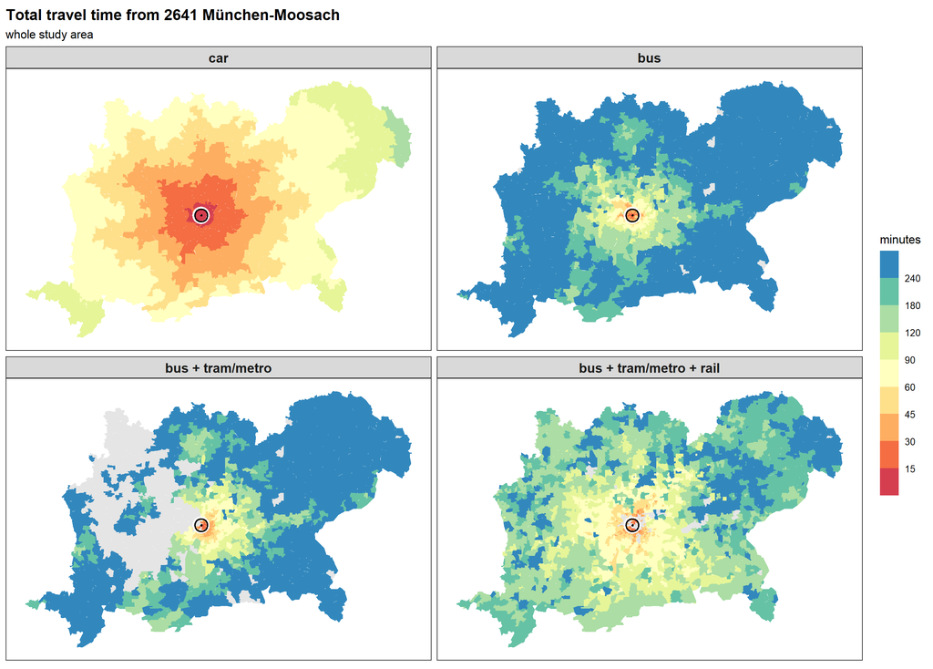

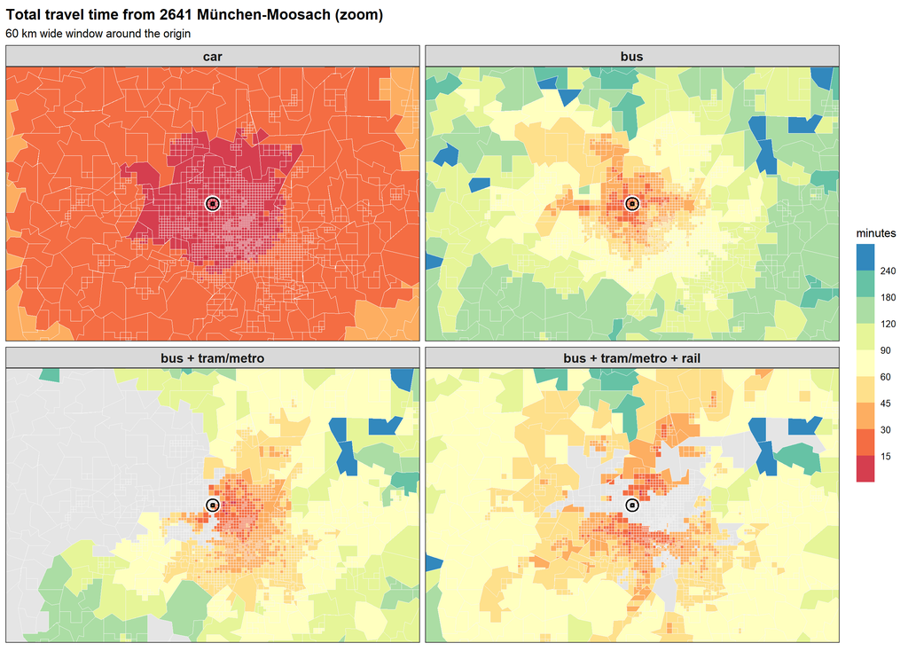

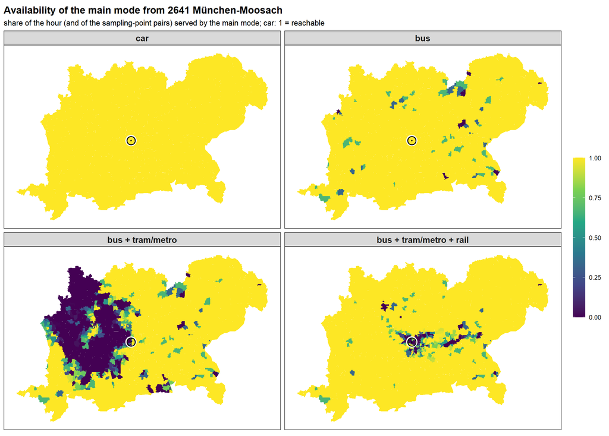

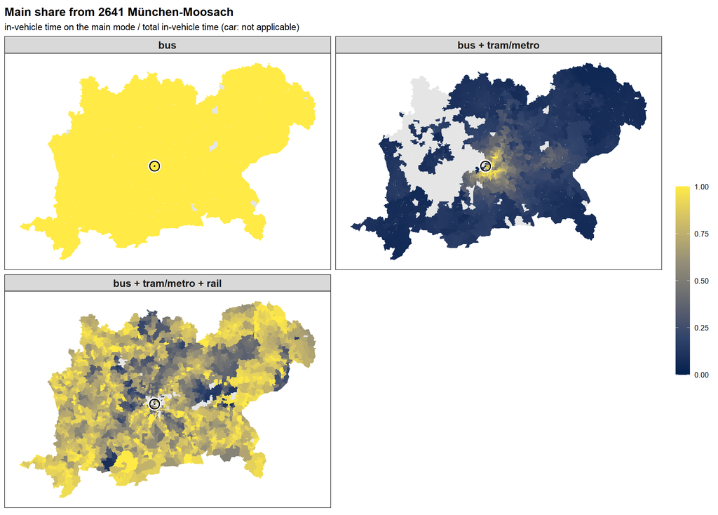

**From 3441 München-Fürstenried West**

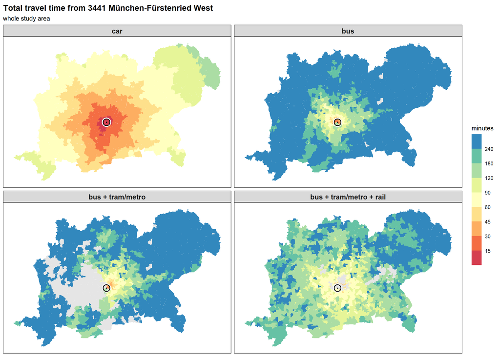

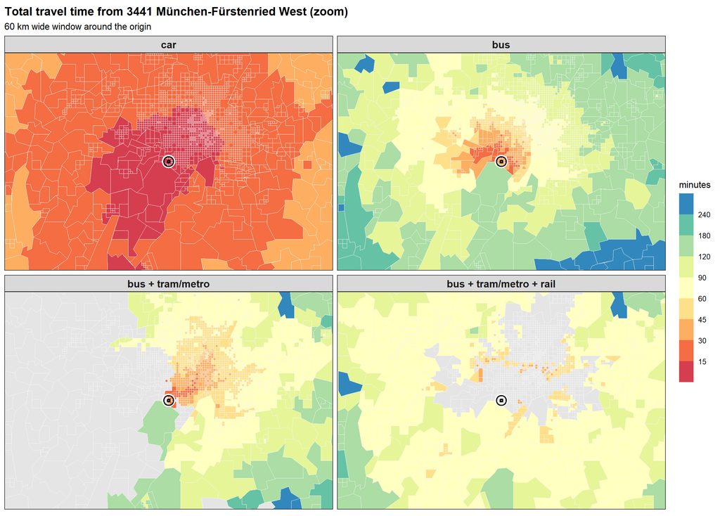

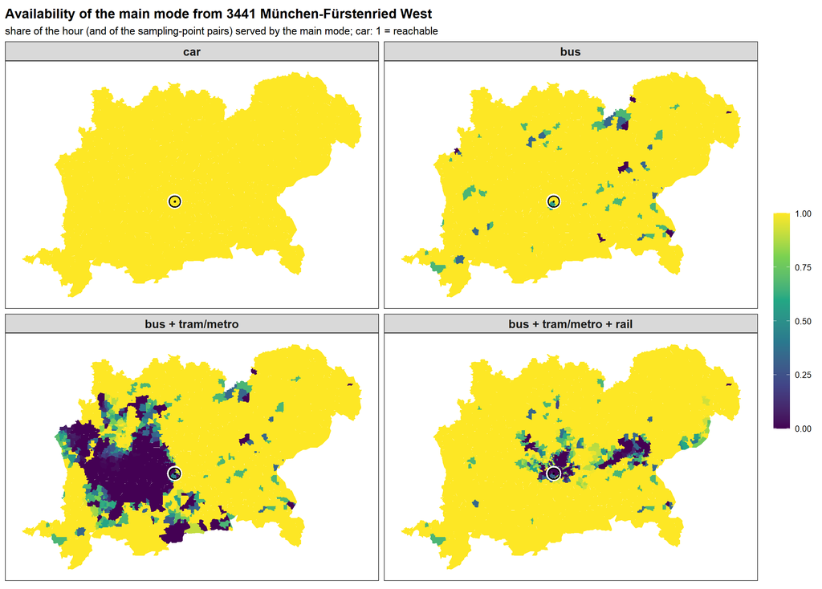

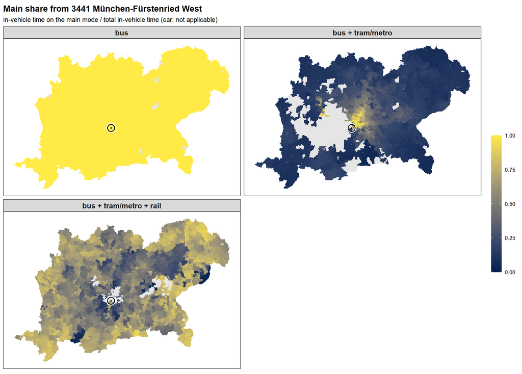

**From 517 Augsburg**

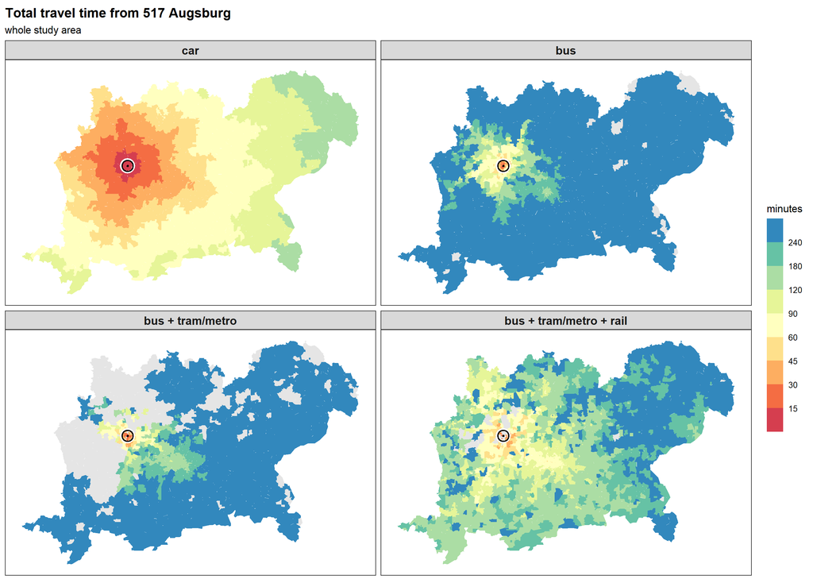

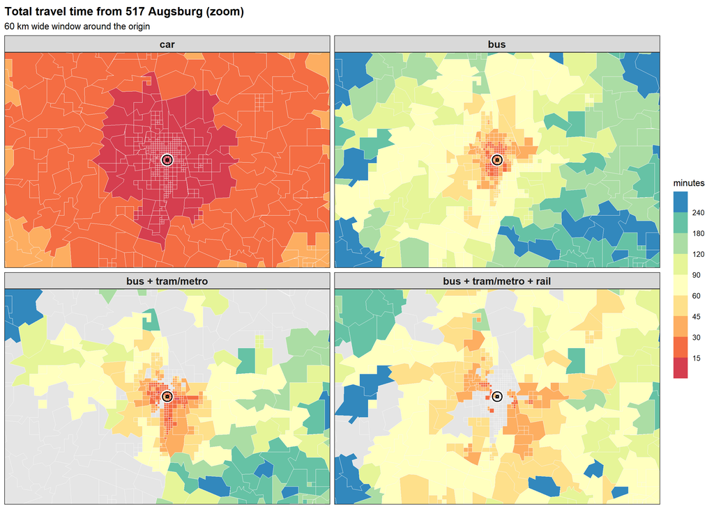

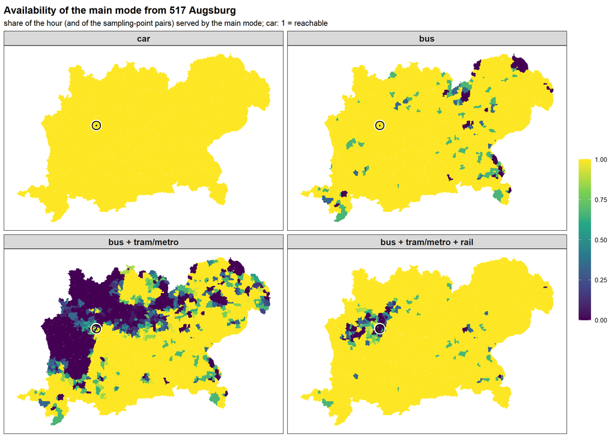

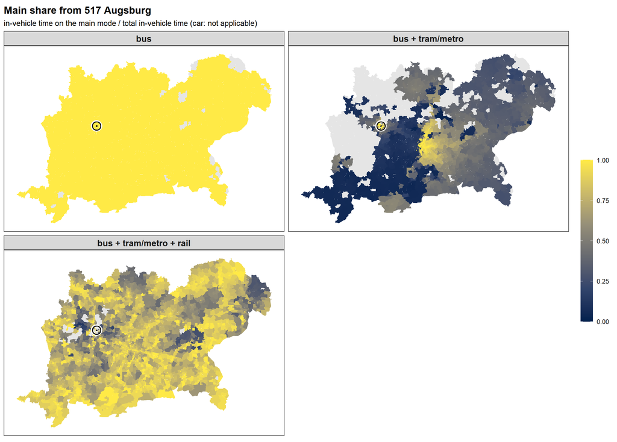

**From 4405 Rosenheim**

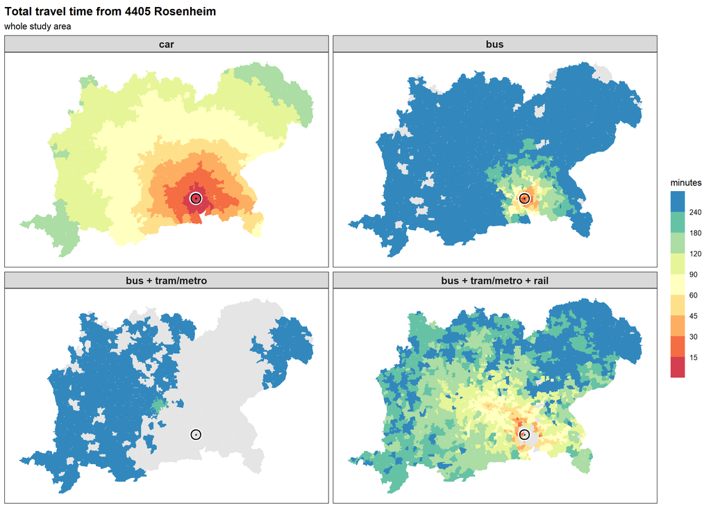

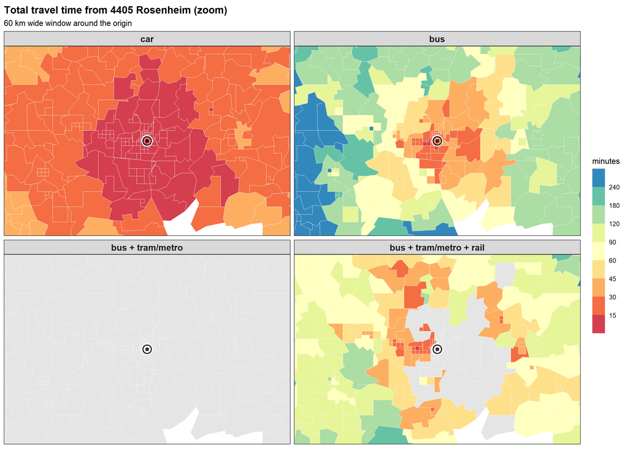

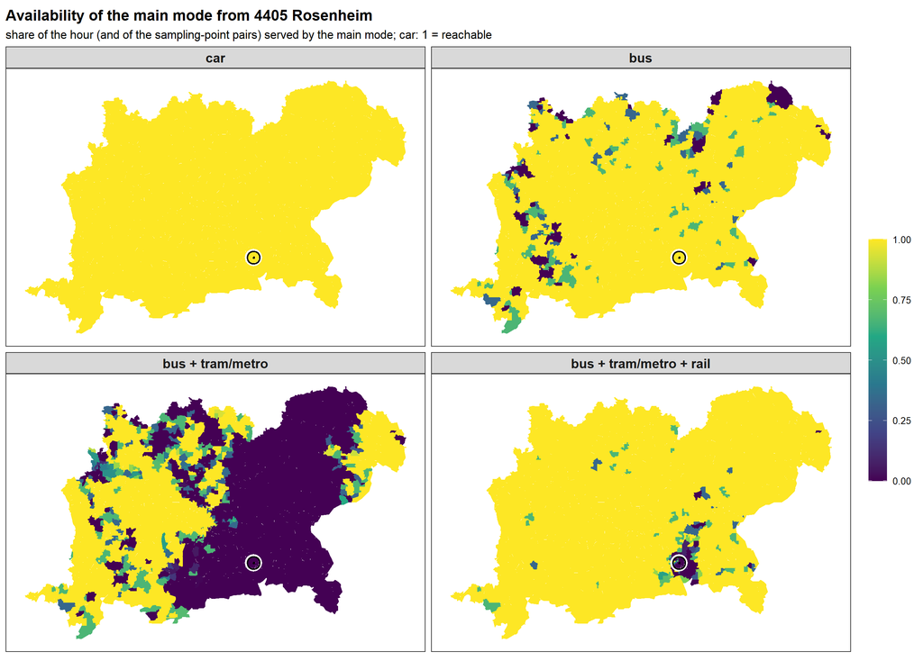

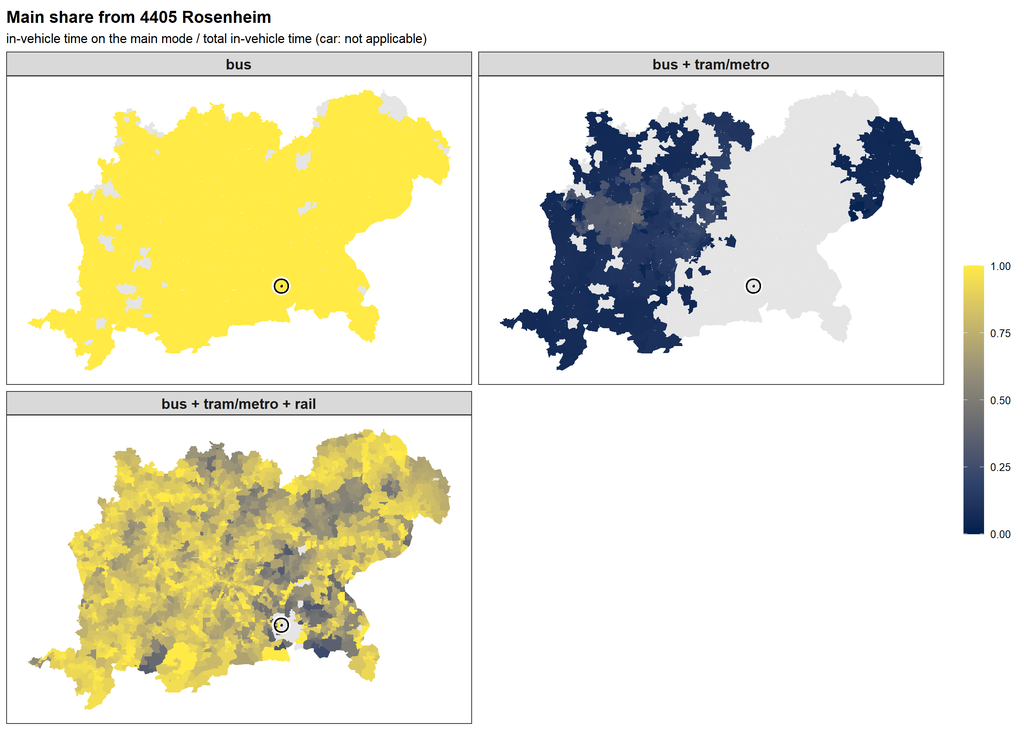

**From 3084 München-Maxvorstadt**

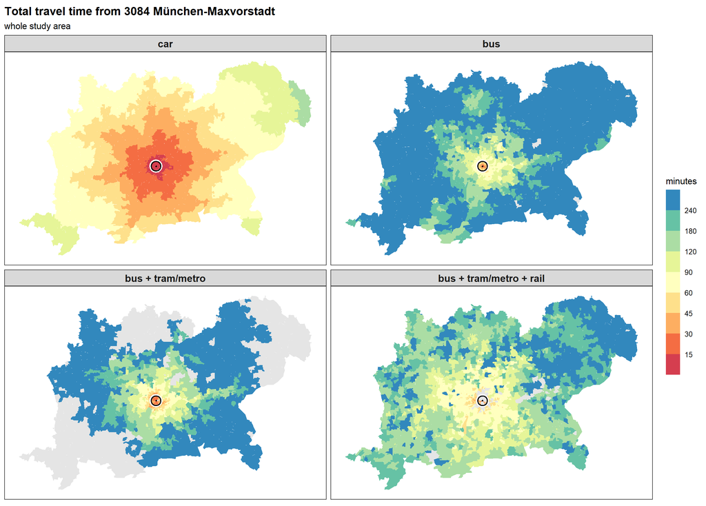

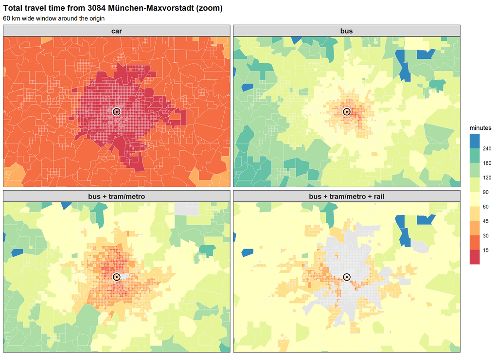

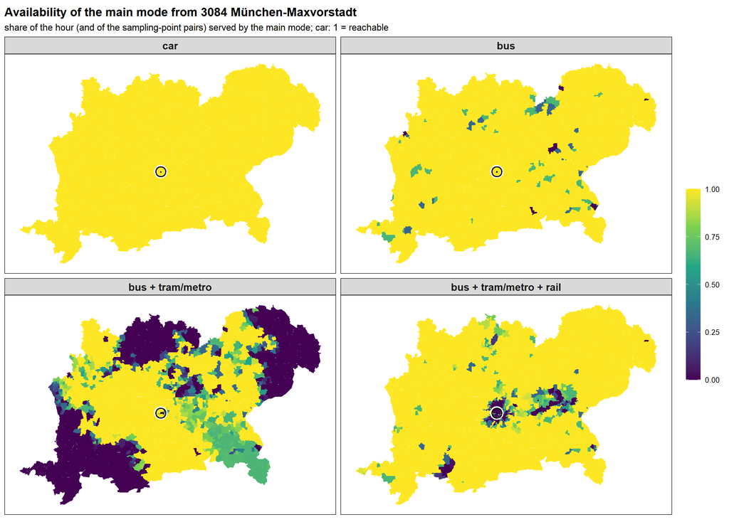

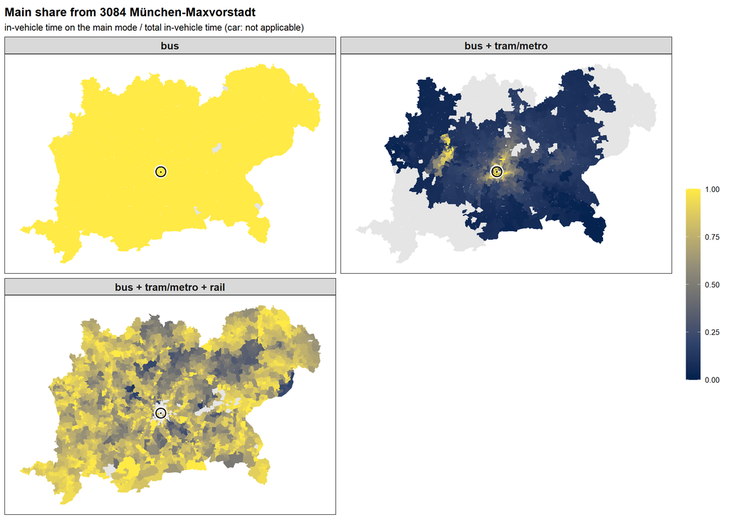

**Region-wide (all origins)**